# Problem Set 1: Advanced Empirical Research Methods

Romu Meango

MT 2025

# Nonparametric Regression

The main package to use is `locpol`. Consider the following data generating process:

$$\begin{array}{l}
X \sim \mathcal{U}[0,1]\\
Y_1= X^2 - X + 1 + \varepsilon_1, \text{ with } \varepsilon_1 \sim N(0,0.1)\\
Y_0= -0.5 X^2 +1.5 X + \varepsilon_0, \text{ with } \varepsilon_0 \sim N(0,0.5)\\
D = 1\{X > U\}, \text{ where } \sim \mathcal{U}[0,1]\\
Y = Y_{1} D + (1-D) Y_{0}
\end{array}$$

1. Set the seed of your random number draw to (34562712).

```r
set.seed(34562712)
```

2. Simulate the draws for $N=1,000$ observations.

```r
library(dplyr)
library(broom)
library(tidyverse)

N=1000
## ---- Generate Simulation data
df <- data.frame(x = runif(N))
df$y1 <- df$x^2 - df$x + 1 + rnorm(N, sd = 0.1)
df$y0 <- -0.5*df$x^2 + 1.5*df$x + rnorm(N, sd = 0.5)

df$D <- as.numeric(ifelse(df$x > runif(N) , 1,0))
summary(df$D)
```

```
##    Min. 1st Qu.  Median    Mean 3rd Qu.    Max.
##   0.000   0.000   1.000   0.518   1.000   1.000
```

```r
df<-df%>%
  mutate(Y = ifelse(D>0.5,y1,y0))
```

Here is the True TE is the population:

```r
# True TE
mean(df$y1 - df$y0)
```

```
## [1] 0.2422134
```

3. Write a function `locpol_TE` that takes the observations $Y$ and $D$ as input and estimates $p(X_i), m_{nh}^d(X_i)$ and $\mu_{nh}^d(X_i)$ for each individual $i$ in the sample, using the function `locpol` and local linear regression (i.e `deg = 1`).

```r
# A routine to compute the ATE
library(locpol)
library(tidyverse)
library(broom)

local_TE <- function(data,
                     outcome,
                     treatment,
                     x){
  # Renaming the columns for convenience
  # (i.e. not using {{ }} afterwards)
  data <- data %>%
    rename(outcome := {{outcome}},
           treatment := {{treatment}},
           x := {{x}})

  r1 <- locpol(outcome~x,data[data$treatment==1,],deg = 1,xeval=data$x)
  r0 <- locpol(outcome~x,data[data$treatment==0,],deg = 1,xeval=data$x)

  m1 <- r1$lpFit$outcome
  m0 <- r0$lpFit$outcome

  prop_hat <- locpol(treatment~x,data=data,deg = 1,xeval=data$x)
  prop_score <- prop_hat$lpFit$treatment

  data <- data%>%
  mutate(Y1_hat = outcome*treatment,
         Y0_hat = outcome*(1-treatment))

  tmpEY1_hat <- locpol(Y1_hat~x,data=data,deg = 1,xeval=data$x)
  tmpEY0_hat <- locpol(Y0_hat~x,data=data,deg = 1,xeval=data$x)

  EY1_hat <- tmpEY1_hat$lpFit$Y1_hat
  EY0_hat <- tmpEY0_hat$lpFit$Y0_hat

  # Append the new moment
  data <- data%>%
    arrange(x) %>% # to append the correct moments tot he correct x, we need to order by x
    mutate(m1 = m1,
           m0 = m0,
           mu0 = EY0_hat/(1-prop_score),
           mu1 = EY1_hat/prop_score,
           prop_score = prop_score)%>%
    mutate(ATT_1 = m1-m0,
           ATT_2 = mu1 - mu0)

  # ATE - from nonparametric regression
  ATE_1 <- data%>%
    pull(ATT_1[]) %>%
    mean()
  #print(ATE_1)

  # ATE - from re-weighted nonparametric regression
  ATE_2 <- data%>%
    pull(ATT_2) %>%
    mean()
  #print(ATE_2)

  bout <- c(ATE_1,ATE_2)
  return(bout)
}

local_TE(data=df, outcome = Y, treatment = D, x = x)
```

```
## [1] 0.2362907 0.3166981
```

4. Look at the help for the function `boot()`: Write a bootstrap procedure to obtain the s.e. of the ATE estimator. Compare the standard errors for $B=100$ bootstrap replications.

```r
library(boot)

local_TE_boot <- function(data, index = 1:nrow(data)) {

  # Slicing with the bootstrap index
  # (this enables the "sampling with replacement")
  data <- data %>%
    slice(index)

  # Renaming the columns for convenience
  # (i.e. not using {{ }} afterwards)
  data <- data %>%
    rename(outcome := Y,
           treatment := D,
           x := x)

  r1 <- locpol(outcome~x,data[data$treatment==1,],deg = 1,xeval=data$x)
  r0 <- locpol(outcome~x,data[data$treatment==0,],deg = 1,xeval=data$x)

  m1 <- r1$lpFit$outcome
  m0 <- r0$lpFit$outcome

  prop_hat <- locpol(treatment~x,data=data,deg = 1,xeval=data$x)
  prop_score <- prop_hat$lpFit$treatment

  data <- data%>%
  mutate(Y1_hat = outcome*treatment,
         Y0_hat = outcome*(1-treatment))

  tmpEY1_hat <- locpol(Y1_hat~x,data=data,deg = 1,xeval=data$x)
  tmpEY0_hat <- locpol(Y0_hat~x,data=data,deg = 1,xeval=data$x)

  EY1_hat <- tmpEY1_hat$lpFit$Y1_hat
  EY0_hat <- tmpEY0_hat$lpFit$Y0_hat

  # Append the new moment
  data <- data%>%
    arrange(x) %>% # to append the correct moments tot he correct x, we need to order by x
    mutate(m1 = m1,
           m0 = m0,
           mu0 = EY0_hat/(1-prop_score),
           mu1 = EY1_hat/prop_score,
           prop_score = prop_score)%>%
    mutate(ATT_1 = m1-m0,
           ATT_2 = mu1 - mu0)

  # ATE - from nonparametric regression
  ATE_1 <- data%>%
    pull(ATT_1[]) %>%
    mean()
  #print(ATE_1)

  # ATE - from re-weighted nonparametric regression
  ATE_2 <- data%>%
    pull(ATT_2) %>%
    mean()
  #print(ATE_2)

  bout <- c(ATE_1,ATE_2)
  return(bout)
}

b <- suppressWarnings(boot(df, local_TE_boot, R = 100))
b
```

```
##
## ORDINARY NONPARAMETRIC BOOTSTRAP
##
##
## Call:
## boot(data = df, statistic = local_TE_boot, R = 100)
##
##
## Bootstrap Statistics :
##      original     bias    std. error
## t1* 0.2362907 0.01009939  0.04157356
## t2* 0.3166981 1.36121576 13.36305697
```

The bootstrap sometimes struggles with the first estimator, producing in some sub-samples a `NA` value. This is presumably because the nonparametric regression is conducted on the restricted (smaller samples).

The variance of the second estimator is much larger. This is because we have propensity score coming close to 0 and 1. One way to reduce this is to trim the sample for high values and low values.

# Counterfactual Analysis

A valid question for a counterfactual analysis is: how does the treatment affects the distribution of outcomes? We have seen during the lecture that the distribution effect can be written as weighted average:
$$DE(y) = F_{<0,1>}(y) - F_{<0,0>}(y) = \mathbb{E}_{X \vert D=0}\bigl[{ \mathbb{E}\left({ 1\left\{{Y \le y}\right\} (\theta(X) - 1) \vert X, D=0}\right)}\bigr]$$
where $\theta(x) := \dfrac{ P(D=1 \vert x)/ P(D=1)}{P(D=0 \vert x)/P(D=0)}$.

Using the data from Lalonde (1986) and the script `SOO_material_weighting.R` in the course material [(here)](https://canvas.ox.ac.uk/courses/167480/files/5142474/download?download_frd=1):

1. Write a function to estimate $DE(y)$.

```r
# For extracting data
library(twang)
data(lalonde)


lalonde$treat_fac <- factor(lalonde$treat,
                            levels = 0:1,
                            labels = c("Untreated", "Treated"))

lreg <- glm(treat ~ age + educ + black + hispan + nodegree +
              married + re74 + re75, data = lalonde, family = binomial(link = 'logit'))

p_hat <- predict(lreg, type = 'response')
lalonde_augm <- augment(lreg,lalonde, type.predict = 'response')

# A routine to compute DE
DE_at_y <- function(data,
                     outcome,
                     treatment,
                     prop_score,
                     y) {

  # Renaming the columns for convenience
  # (i.e. not using {{ }} afterwards)
  data <- data %>%
    rename(outcome := {{outcome}},
           treatment := {{treatment}},
           prop_score := {{prop_score}})
  data <- data %>%
        filter(prop_score>0.1)%>%
    mutate(ind_Y = (as.numeric(outcome  <= y)),
          sum_treated = sum(treatment),
          sum_untreated = length(treatment)-sum(treatment))

  # Estimation itself
  data %>%
    mutate(DE = ind_Y*((prop_score/(1-prop_score))*(sum_untreated/sum_treated)-1))%>%
    filter(treatment==0)%>%
    pull(DE) %>%
    mean()

}

DE_at_y(data=lalonde_augm ,outcome = re78, treatment = treat, prop_score = .fitted, y = 10000 )
```

```
## [1] 0.009605139
```

2. Plot the resulting $DE(y)$. What can we conclude about selection into the treatment in this sample?

First let’s have a look at the empirical distribution of the outcome for treated and untreated: $F_{Y \vert D=1}(y) - F_{Y\vert D=0}(y)$

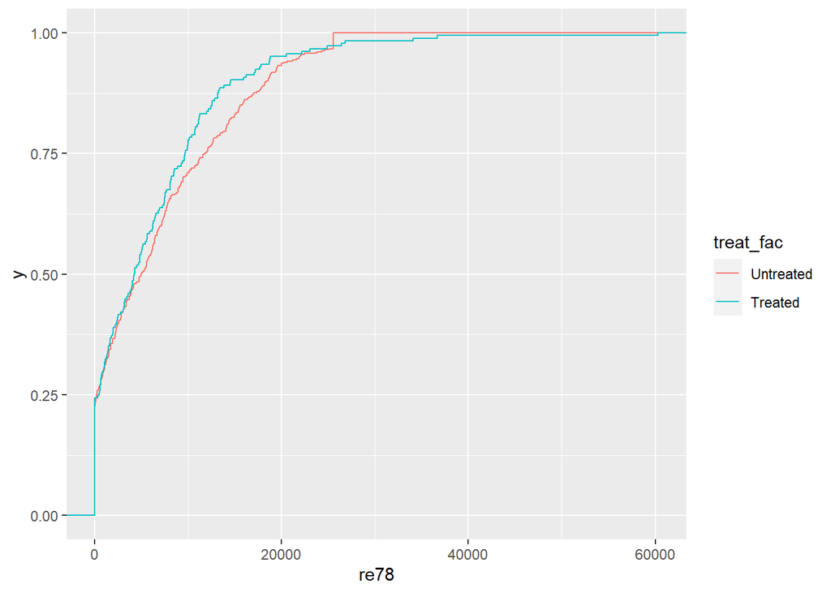

```r
library(ggplot2)
ggplot(lalonde_augm, aes(x = re78, colour = treat_fac)) +
  stat_ecdf()
```

The untreated have slightly larger wage potential than the treated.

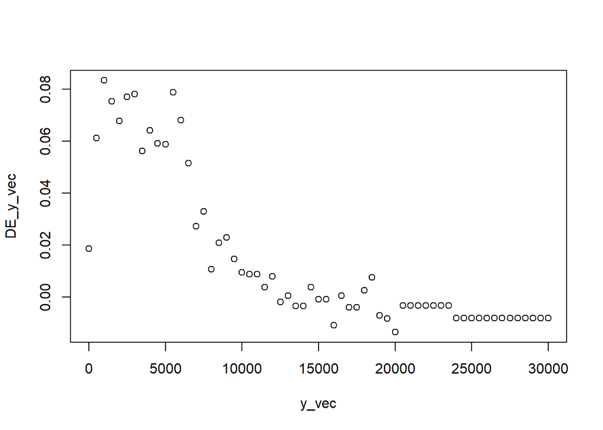

```r
y_vec <- seq(0,30000,500)
DE_y_vec <- sapply(y_vec ,
                   function(i) DE_at_y(data=lalonde_augm ,
                                       outcome = re78,
                                       treatment = treat,
                                       prop_score = .fitted,
                                       y = i ))
plot(y_vec,DE_y_vec)
```

# Analysis with unconfoudedness assumption

This exercise presents the essential steps of an empirical analysis under the unconfoundedness assumption. Here are few packages we need:

```r
library(marginaleffects)
library(dplyr)
```

1. We will use the a subset of the data from Lalonde (1986). Extract the data from the library `twang`, using the command `data(lalonde)`. Present a table of summary statistics. One option is the command `datasummary_skim` from the package `modelsummary`. The treatment is participation to a training program for individuals with low labour market attachment The outcome of interest is the income in the year 1978: variable `re78`. The Control includes a list of demographic characteristics and the income in the years before the program: `re75` and `re74`.

```r
# For extracting data
library(twang)
data(lalonde)

library(modelsummary)
datasummary_skim(lalonde)
```

|  | Unique (#) | Missing (%) | Mean | SD | Min | Median | Max |  |
| --- | --- | --- | --- | --- | --- | --- | --- | --- |
| treat | 2 | 0 | 0.3 | 0.5 | 0.0 | 0.0 | 1.0 |  |
| age | 40 | 0 | 27.4 | 9.9 | 16.0 | 25.0 | 55.0 |  |
| educ | 19 | 0 | 10.3 | 2.6 | 0.0 | 11.0 | 18.0 |  |
| black | 2 | 0 | 0.4 | 0.5 | 0.0 | 0.0 | 1.0 |  |
| hispan | 2 | 0 | 0.1 | 0.3 | 0.0 | 0.0 | 1.0 |  |
| married | 2 | 0 | 0.4 | 0.5 | 0.0 | 0.0 | 1.0 |  |
| nodegree | 2 | 0 | 0.6 | 0.5 | 0.0 | 1.0 | 1.0 |  |
| re74 | 358 | 0 | 4557.5 | 6478.0 | 0.0 | 1042.3 | 35040.1 |  |
| re75 | 356 | 0 | 2184.9 | 3295.7 | 0.0 | 601.5 | 25142.2 |  |
| re78 | 457 | 0 | 6792.8 | 7470.7 | 0.0 | 4759.0 | 60307.9 |  |

Note: A good number of individual have zero income. This speaks for a non-linear model. There seems to be a large enough pool of control observations. The variables `re74` and `re75` may serve as placebo.

2. Verify if the covariates are balanced across treatment groups. You can use command `data_summary_balance`.

```r
datasummary_balance(~treat,data = lalonde)
```

|  | 0 Mean | 0 Std. Dev. | 1 Mean | 1 Std. Dev. | Diff. in Means | Std. Error |
| --- | --- | --- | --- | --- | --- | --- |
| age | 28.0 | 10.8 | 25.8 | 7.2 | -2.2 | 0.7 |
| educ | 10.2 | 2.9 | 10.3 | 2.0 | 0.1 | 0.2 |
| black | 0.2 | 0.4 | 0.8 | 0.4 | 0.6 | 0.0 |
| hispan | 0.1 | 0.3 | 0.1 | 0.2 | -0.1 | 0.0 |
| married | 0.5 | 0.5 | 0.2 | 0.4 | -0.3 | 0.0 |
| nodegree | 0.6 | 0.5 | 0.7 | 0.5 | 0.1 | 0.0 |
| re74 | 5619.2 | 6788.8 | 2095.6 | 4886.6 | -3523.7 | 486.3 |
| re75 | 2466.5 | 3292.0 | 1532.1 | 3219.3 | -934.4 | 285.1 |
| re78 | 6984.2 | 7294.2 | 6349.1 | 7867.4 | -635.0 | 677.2 |

Notes: The data do not really seem to be balanced on several dimensions: age, race, marital status, income before treatment. That should be expected: The training is meant for individuals with the worst outcomes on the labour market.

3. Provide and estimate of the propensity score, controlling for the available observable characteristics. Draw the density. Is there a concern for estimation given the uncovered distribution?

```r
library(estimatr)
lreg <- glm(treat ~ age + educ + black + hispan + nodegree +
              married + re74 + re75, data = lalonde, family = binomial(link = 'logit'))
summary(lreg)
```

```
##
## Call:
## glm(formula = treat ~ age + educ + black + hispan + nodegree +
##     married + re74 + re75, family = binomial(link = "logit"),
##     data = lalonde)
##
## Deviance Residuals:
##     Min       1Q   Median       3Q      Max
## -1.7645  -0.4736  -0.2862   0.7508   2.7169
##
## Coefficients:
##               Estimate Std. Error z value Pr(>|z|)
## (Intercept) -4.729e+00  1.017e+00  -4.649 3.33e-06 ***
## age          1.578e-02  1.358e-02   1.162  0.24521
## educ         1.613e-01  6.513e-02   2.477  0.01325 *
## black        3.065e+00  2.865e-01  10.699  < 2e-16 ***
## hispan       9.836e-01  4.257e-01   2.311  0.02084 *
## nodegree     7.073e-01  3.377e-01   2.095  0.03620 *
## married     -8.321e-01  2.903e-01  -2.866  0.00415 **
## re74        -7.178e-05  2.875e-05  -2.497  0.01253 *
## re75         5.345e-05  4.635e-05   1.153  0.24884
## ---
## Signif. codes:  0 '***' 0.001 '**' 0.01 '*' 0.05 '.' 0.1 ' ' 1
##
## (Dispersion parameter for binomial family taken to be 1)
##
##     Null deviance: 751.49  on 613  degrees of freedom
## Residual deviance: 487.84  on 605  degrees of freedom
## AIC: 505.84
##
## Number of Fisher Scoring iterations: 5
```

```r
p_hat <- predict(lreg, type = 'response')
head(p_hat)
```

```
##         1         2         3         4         5         6
## 0.6387699 0.2246342 0.6782439 0.7763241 0.7016387 0.6990699
```

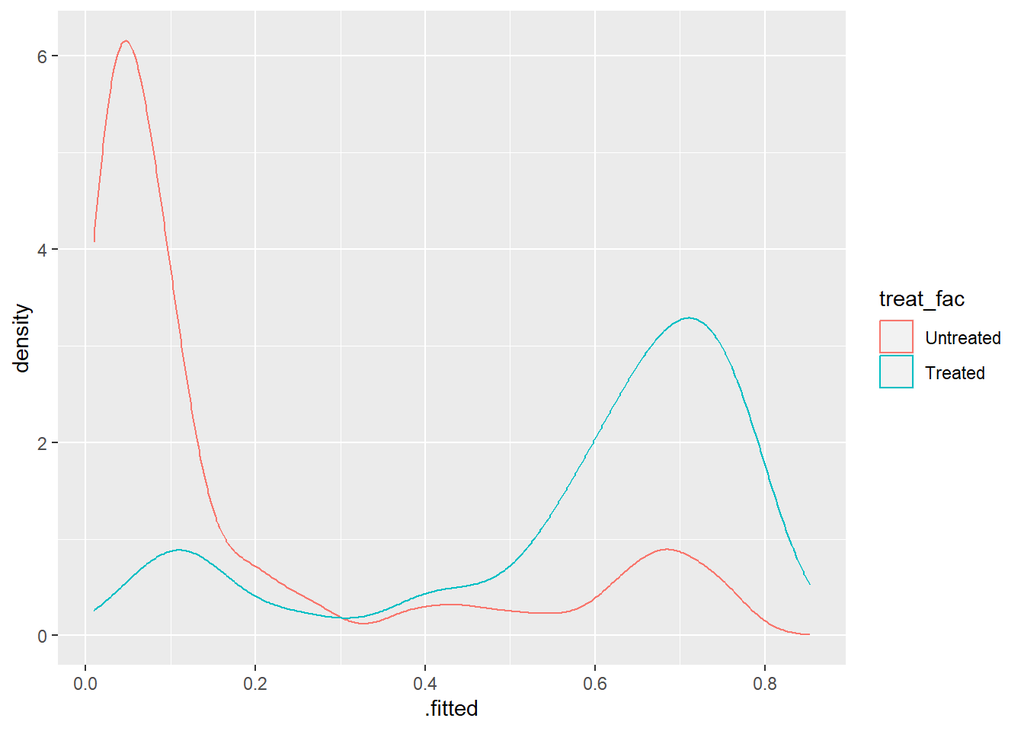

```r
library(broom)
lalonde_augm <- augment(lreg,lalonde, type.predict = 'response')

# Kernel density of propensity score
lalonde_augm$treat_fac <- factor(lalonde$treat,
                            levels = 0:1,
                            labels = c("Untreated", "Treated"))

library(ggplot2)
ggplot(data=lalonde_augm,aes(x = .fitted, colour = treat_fac))+
  geom_density()
```

The propensity score is close to zero especially for the untreated. This may cause instability of the IPW, and sensitivity to trimming, when estimating the ATE.

4. What would be your preferred estimation method?

The following argument speaks for matching: - Non linearity in the outcome - good pool of controls - possible instability of IPW. But we can still run and report all three estimates

5. In this question, we will use a regression model to assess the ATT. 1 - Perform a regression of `re78` on the independent varaibles, interacting the treatment with each of them. 2- Compute the ATT using the function `comparisons` in the package `marginal effects`.

```r
# Fully interacted model

fitS <- lm(re78 ~ treat *(age + educ + black + hispan + nodegree + nodegree + re74 + married + re74 + re75),
           data = lalonde)

# Compute ATT
compS <- comparisons(fitS,
                     variables = "treat",
                     vcov = "HC3",
                     newdata = subset(lalonde, treat == 1))
summary(compS)
```

```
##    Term Contrast Effect Std. Error z value Pr(>|z|) 2.5 % 97.5 %
## 1 treat    1 - 0   1648      826.1   1.994 0.046102 28.49   3267
##
## Model type:  lm
## Prediction type:  response
```

5. In this question, we will use a IPW to assess the ATT. 1 - Read the help to the package WeightIt. 2- Use the function `weightit` to compute balancing weights 3- Compute the ATT using the function `svydesign` in the package `survey`.

```r
## ---- IPW: Computing ATT Using the package WeightIt
library(cobalt)
library(WeightIt)

#Balancing covariates between treatment groups (binary)
(W.out <- weightit(treat ~ age + educ + married + black + hispan +
                     nodegree + re74+re75, data = lalonde,
                   method = "ps", estimand = "ATT"))
```

```
## A weightit object
##  - method: "ps" (propensity score weighting)
##  - number of obs.: 614
##  - sampling weights: none
##  - treatment: 2-category
##  - estimand: ATT (focal: 1)
##  - covariates: age, educ, married, black, hispan, nodegree, re74, re75
```

```r
summary(W.out)
```

```
##                  Summary of weights
##
## - Weight ranges:
##
##            Min                                  Max
## treated 1.0000         ||                    1.0000
## control 0.0092 |---------------------------| 3.7432
##
## - Units with 5 most extreme weights by group:
##
##               7      6      5      4      3
##  treated      1      1      1      1      1
##             597    573    381    411    303
##  control 3.0301 3.0592 3.2397 3.5231 3.7432
##
## - Weight statistics:
##
##         Coef of Var   MAD Entropy # Zeros
## treated       0.000 0.000  -0.000       0
## control       1.818 1.289   1.098       0
##
## - Effective Sample Sizes:
##
##            Control Treated
## Unweighted  429.       185
## Weighted     99.82     185
```

```r
bal.tab(W.out)
```

```
## Balance Measures
##                Type Diff.Adj
## prop.score Distance  -0.0205
## age         Contin.   0.1188
## educ        Contin.  -0.0284
## married      Binary   0.0186
## black        Binary  -0.0022
## hispan       Binary   0.0002
## nodegree     Binary   0.0184
## re74        Contin.  -0.0021
## re75        Contin.   0.0110
##
## Effective sample sizes
##            Control Treated
## Unadjusted  429.       185
## Adjusted     99.82     185
```

```r
library(survey)
d.w <- svydesign(~1, weights = W.out$weights, data = lalonde)
fit <- svyglm(re78 ~ treat, design = d.w)
summary(fit)
```

```
##
## Call:
## svyglm(formula = re78 ~ treat, design = d.w)
##
## Survey design:
## svydesign(~1, weights = W.out$weights, data = lalonde)
##
## Coefficients:
##             Estimate Std. Error t value Pr(>|t|)
## (Intercept)   5135.1      588.9   8.719   <2e-16 ***
## treat         1214.1      824.7   1.472    0.142
## ---
## Signif. codes:  0 '***' 0.001 '**' 0.01 '*' 0.05 '.' 0.1 ' ' 1
##
## (Dispersion parameter for gaussian family taken to be 49598072)
##
## Number of Fisher Scoring iterations: 2
```

```r
confint(fit)
```

```
##                 2.5 %   97.5 %
## (Intercept) 3978.4650 6291.680
## treat       -405.5604 2833.703
```

6. Alternatively, use the function `treatweight` in the package `causalweight` to estimate the ATT.

```r
## ---- IPW: Computing ATT Using the package causalweight (Trimming is more transparent - command more cumbersome )
df<-lalonde
controls.x <- matrix(c(df$age,df$educ,df$married,df$nodegree,df$black,df$hispan,df$re74,df$re75),ncol=8)

library(causalweight)
treatweight(y=df$re78,d=df$treat,x=controls.x,trim=0.05,ATET=TRUE,logit=TRUE,boot=199)
```

```
## $effect
## [1] 1214.071
##
## $se
## [1] 764.4845
##
## $pval
## [1] 0.1122657
##
## $y1
## [1] 6349.144
##
## $y0
## [1] 5135.072
##
## $ntrimmed
## [1] 0
```

One can assess the sensitivity to the trimming by changing the trimming parameter.

```r
treatweight(y=df$re78,d=df$treat,x=controls.x,trim=0.1,ATET=TRUE,logit=TRUE,boot=199)
```

```
## $effect
## [1] 1214.071
##
## $se
## [1] 776.0043
##
## $pval
## [1] 0.1176964
##
## $y1
## [1] 6349.144
##
## $y0
## [1] 5135.072
##
## $ntrimmed
## [1] 0
```

```r
treatweight(y=df$re78,d=df$treat,x=controls.x,trim=0.01,ATET=TRUE,logit=TRUE,boot=199)
```

```
## $effect
## [1] 1214.071
##
## $se
## [1] 874.6552
##
## $pval
## [1] 0.1651197
##
## $y1
## [1] 6349.144
##
## $y0
## [1] 5135.072
##
## $ntrimmed
## [1] 0
```

7. The last method we have seen is matching on observable characteristics. We will use the package `MatchIt`. Here is a useful [link](https://cran.r-project.org/web/packages/MatchIt/vignettes/MatchIt.html).
   1. Produce a match sampled using the function `matchit` (without replacement).
   2. Use balance plots to assess the quality of the matching. Can you do something to improve the matching and ensure overlap?
   3. Following Imbens (2015) match with replacement and calculate the ATT with bias adjustment or using blocks of the propensity score.

```r
## ---- Matching the data - using MatchIt Package

# Match without replacement
library(MatchIt)
# Using propensity score
match0 <- matchit(treat~age + educ + married + black + hispan +
                  nodegree + re74+re75, data = lalonde, distance = "glm",
                  method = "nearest", ratio=1, replace = FALSE)
summary(match0)
```

```
##
## Call:
## matchit(formula = treat ~ age + educ + married + black + hispan +
##     nodegree + re74 + re75, data = lalonde, method = "nearest",
##     distance = "glm", replace = FALSE, ratio = 1)
##
## Summary of Balance for All Data:
##          Means Treated Means Control Std. Mean Diff. Var. Ratio eCDF Mean
## distance        0.5774        0.1822          1.7941     0.9211    0.3774
## age            25.8162       28.0303         -0.3094     0.4400    0.0813
## educ           10.3459       10.2354          0.0550     0.4959    0.0347
## married         0.1892        0.5128         -0.8263          .    0.3236
## black           0.8432        0.2028          1.7615          .    0.6404
## hispan          0.0595        0.1422         -0.3498          .    0.0827
## nodegree        0.7081        0.5967          0.2450          .    0.1114
## re74         2095.5737     5619.2365         -0.7211     0.5181    0.2248
## re75         1532.0553     2466.4844         -0.2903     0.9563    0.1342
##          eCDF Max
## distance   0.6444
## age        0.1577
## educ       0.1114
## married    0.3236
## black      0.6404
## hispan     0.0827
## nodegree   0.1114
## re74       0.4470
## re75       0.2876
##
## Summary of Balance for Matched Data:
##          Means Treated Means Control Std. Mean Diff. Var. Ratio eCDF Mean
## distance        0.5774        0.3629          0.9739     0.7566    0.1321
## age            25.8162       25.3027          0.0718     0.4568    0.0847
## educ           10.3459       10.6054         -0.1290     0.5721    0.0239
## married         0.1892        0.2108         -0.0552          .    0.0216
## black           0.8432        0.4703          1.0259          .    0.3730
## hispan          0.0595        0.2162         -0.6629          .    0.1568
## nodegree        0.7081        0.6378          0.1546          .    0.0703
## re74         2095.5737     2342.1076         -0.0505     1.3289    0.0469
## re75         1532.0553     1614.7451         -0.0257     1.4956    0.0452
##          eCDF Max Std. Pair Dist.
## distance   0.4216          0.9740
## age        0.2541          1.3938
## educ       0.0757          1.2474
## married    0.0216          0.8281
## black      0.3730          1.0259
## hispan     0.1568          1.0743
## nodegree   0.0703          1.0106
## re74       0.2757          0.7965
## re75       0.2054          0.7381
##
## Sample Sizes:
##           Control Treated
## All           429     185
## Matched       185     185
## Unmatched     244       0
## Discarded       0       0
```

```r
# Using Mahalanobis distance
match1 <- matchit(treat~age + educ + married + black + hispan +
                  nodegree + re74+re75, data = lalonde, distance = "mahalanobis",
                  method = "nearest", ratio=1, replace = FALSE)
summary(match1)
```

```
##
## Call:
## matchit(formula = treat ~ age + educ + married + black + hispan +
##     nodegree + re74 + re75, data = lalonde, method = "nearest",
##     distance = "mahalanobis", replace = FALSE, ratio = 1)
##
## Summary of Balance for All Data:
##          Means Treated Means Control Std. Mean Diff. Var. Ratio eCDF Mean
## age            25.8162       28.0303         -0.3094     0.4400    0.0813
## educ           10.3459       10.2354          0.0550     0.4959    0.0347
## married         0.1892        0.5128         -0.8263          .    0.3236
## black           0.8432        0.2028          1.7615          .    0.6404
## hispan          0.0595        0.1422         -0.3498          .    0.0827
## nodegree        0.7081        0.5967          0.2450          .    0.1114
## re74         2095.5737     5619.2365         -0.7211     0.5181    0.2248
## re75         1532.0553     2466.4844         -0.2903     0.9563    0.1342
##          eCDF Max
## age        0.1577
## educ       0.1114
## married    0.3236
## black      0.6404
## hispan     0.0827
## nodegree   0.1114
## re74       0.4470
## re75       0.2876
##
## Summary of Balance for Matched Data:
##          Means Treated Means Control Std. Mean Diff. Var. Ratio eCDF Mean
## age            25.8162       24.9189          0.1254     0.5333    0.0692
## educ           10.3459       10.4378         -0.0457     0.8306    0.0111
## married         0.1892        0.2486         -0.1518          .    0.0595
## black           0.8432        0.4649          1.0407          .    0.3784
## hispan          0.0595        0.0595          0.0000          .    0.0000
## nodegree        0.7081        0.6595          0.1070          .    0.0486
## re74         2095.5737     3308.2167         -0.2482     0.8710    0.1016
## re75         1532.0553     1960.6355         -0.1331     1.0081    0.0662
##          eCDF Max Std. Pair Dist.
## age        0.2324          0.6210
## educ       0.0486          0.2930
## married    0.0595          0.1794
## black      0.3784          1.0407
## hispan     0.0000          0.0000
## nodegree   0.0486          0.1070
## re74       0.3405          0.4552
## re75       0.2216          0.4123
##
## Sample Sizes:
##           Control Treated
## All           429     185
## Matched       185     185
## Unmatched     244       0
## Discarded       0       0
```

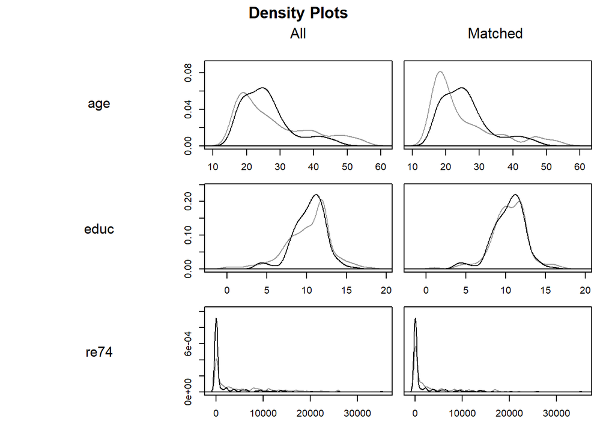

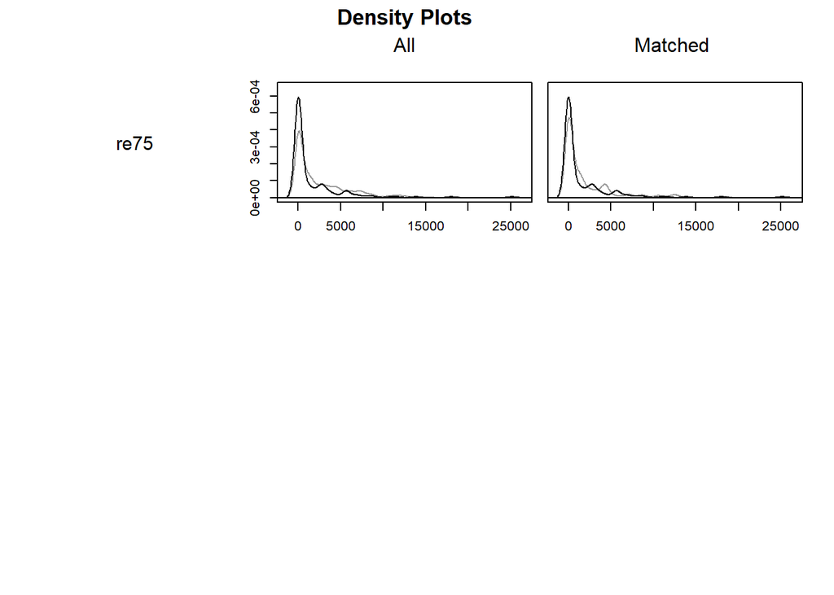

```r
## ---- Assessing Match quality

# Balance plot
plot(match1, type = "density", interactive = FALSE,
     which.xs = ~age+educ+re74+re75)
```

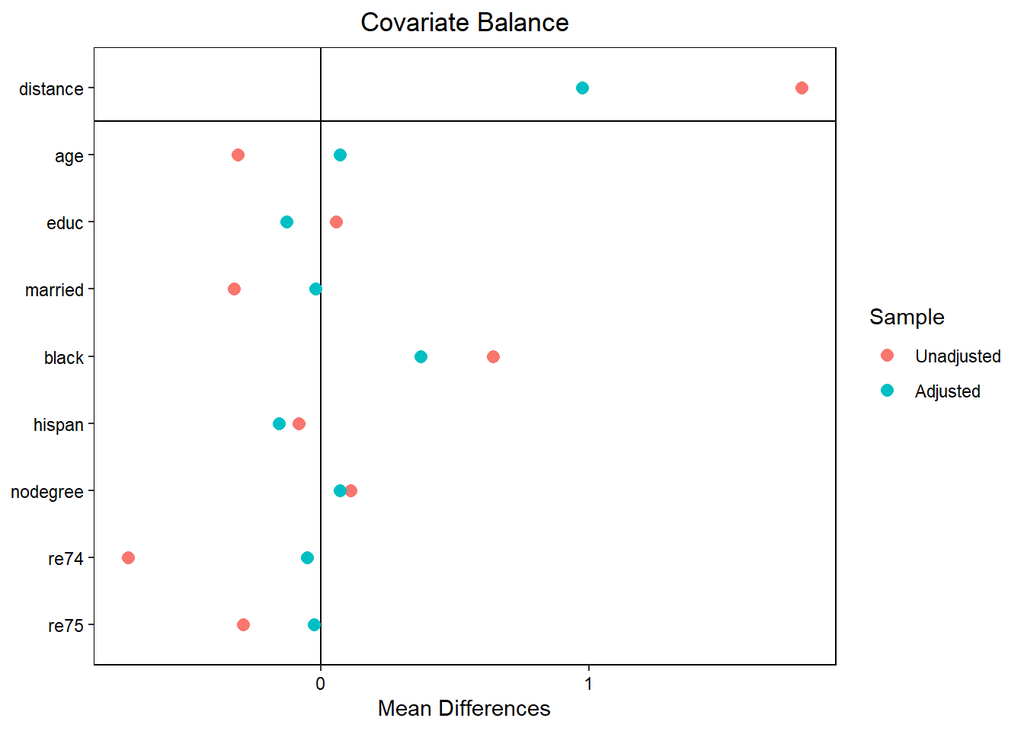

```r
# Graphical representation of mean differnce
love.plot(match0, abs = F)
```

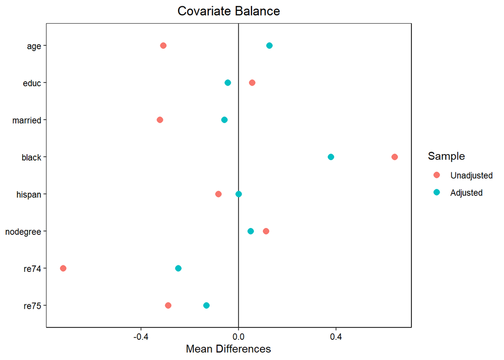

```r
love.plot(match1, abs = F)
```

Most seems fine expect for black, somewhat `age` (the distribution is different). Besides `re74` and `re75` have a seemingly long tail. Their normalised differences (std.diff.) is above close to 0.3. We may want to split to have young and old, and drop too high income.

```r
lalonde_augm <- lalonde%>%
  mutate(old_dummy = ifelse(age>30,1,0)) %>%
  filter(re75<10001 | re74<20000)

# rematching
match0 <- matchit(treat~age + educ + married + black + hispan + old_dummy +
                    nodegree + re74+re75, data = lalonde_augm, distance = "glm",
                  discard = "both", # Enforces the common support
                  method = "nearest", ratio=1, replace = FALSE)
summary(match0)
```

```
##
## Call:
## matchit(formula = treat ~ age + educ + married + black + hispan +
##     old_dummy + nodegree + re74 + re75, data = lalonde_augm,
##     method = "nearest", distance = "glm", discard = "both", replace = FALSE,
##     ratio = 1)
##
## Summary of Balance for All Data:
##           Means Treated Means Control Std. Mean Diff. Var. Ratio eCDF Mean
## distance         0.5864        0.1781          1.7747     1.0379    0.3813
## age             25.7814       28.0047         -0.3099     0.4401    0.0816
## educ            10.3169       10.2118          0.0526     0.4915    0.0352
## married          0.1803        0.5082         -0.8529          .    0.3279
## black            0.8415        0.2047          1.7439          .    0.6368
## hispan           0.0601        0.1435         -0.3510          .    0.0834
## old_dummy        0.1913        0.3294         -0.3513          .    0.1382
## nodegree         0.7158        0.6000          0.2569          .    0.1158
## re74          1816.1809     5451.7036         -0.9010     0.3748    0.2304
## re75          1425.9689     2335.0272         -0.2960     1.0414    0.1388
##           eCDF Max
## distance    0.6596
## age         0.1576
## educ        0.1158
## married     0.3279
## black       0.6368
## hispan      0.0834
## old_dummy   0.1382
## nodegree    0.1158
## re74        0.4523
## re75        0.2913
##
## Summary of Balance for Matched Data:
##           Means Treated Means Control Std. Mean Diff. Var. Ratio eCDF Mean
## distance         0.5621        0.3810          0.7875     0.8425    0.1032
## age             25.5509       26.2156         -0.0926     0.4252    0.0783
## educ            10.2455       10.2455          0.0000     0.5136    0.0277
## married          0.1976        0.2395         -0.1090          .    0.0419
## black            0.8263        0.5210          0.8363          .    0.3054
## hispan           0.0659        0.2216         -0.6550          .    0.1557
## old_dummy        0.2036        0.2395         -0.0914          .    0.0359
## nodegree         0.6946        0.6647          0.0664          .    0.0299
## re74          1959.4251     2455.1960         -0.1229     0.9566    0.0549
## re75          1433.2010     1932.7979         -0.1627     1.1213    0.0831
##           eCDF Max Std. Pair Dist.
## distance    0.3713          0.7881
## age         0.1916          1.3780
## educ        0.0659          2.5269
## married     0.0419          0.9189
## black       0.3054          0.8363
## hispan      0.1557          1.1085
## old_dummy   0.0359          0.9135
## nodegree    0.0299          0.8364
## re74        0.3054          0.8156
## re75        0.2156          0.8128
##
## Sample Sizes:
##           Control Treated
## All           425     183
## Matched       167     167
## Unmatched     198       0
## Discarded      60      16
```

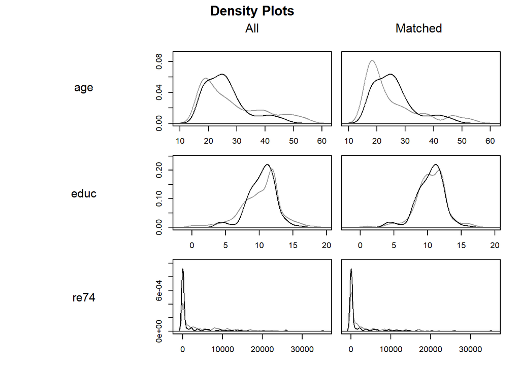

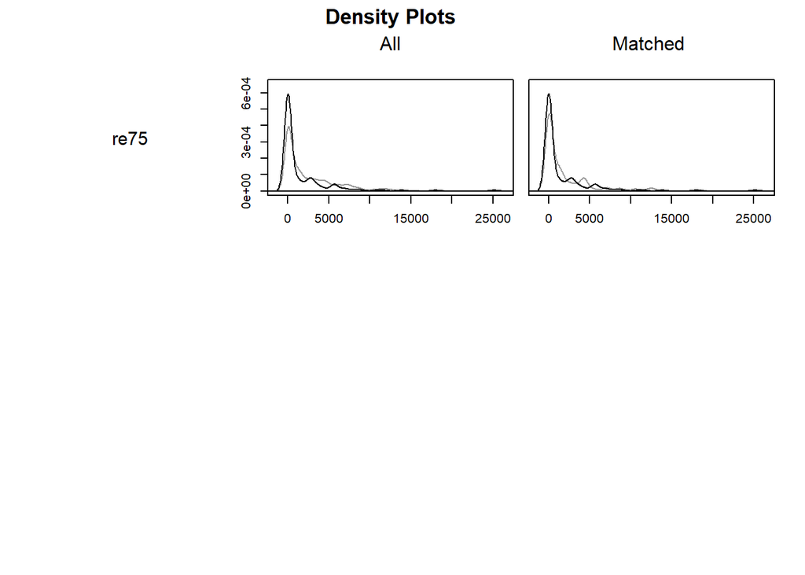

```r
# Balance plot
plot(match1, type = "density", interactive = FALSE,
     which.xs = ~age+educ+re74+re75)
```

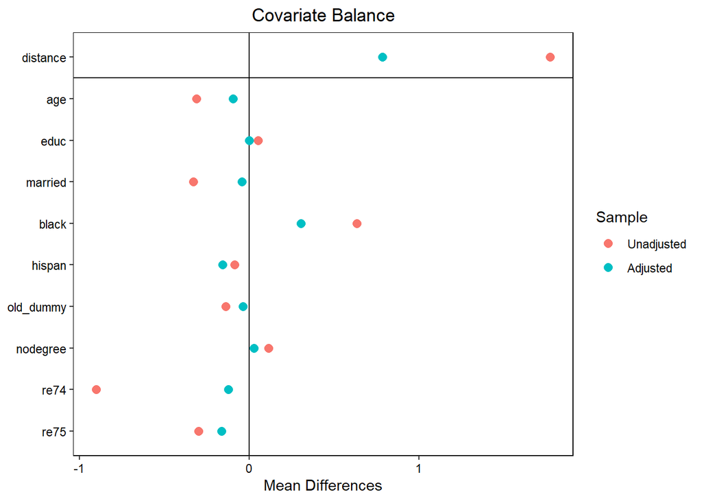

```r
# Graphical representation of mean differnce
love.plot(match0, abs = F)
```

Note: it looks better! There is little one can do about race. Minorities are overrepresented in the treated sample.The same observation may be reused when matching.

```r
## ---- Estimating the ATT with MatchIt
## Using regression adjustment of Imbens(2015)
# Bias adjustment withLinear model with covariates

# Match with replacement
match0 <- matchit(treat~age + educ + married + black + hispan + old_dummy +
                    nodegree + re74+re75, data = lalonde_augm, distance = "glm",
                  discard = "both",
                  method = "nearest", ratio=3, replace = TRUE)
summary(match0)
```

```
##
## Call:
## matchit(formula = treat ~ age + educ + married + black + hispan +
##     old_dummy + nodegree + re74 + re75, data = lalonde_augm,
##     method = "nearest", distance = "glm", discard = "both", replace = TRUE,
##     ratio = 3)
##
## Summary of Balance for All Data:
##           Means Treated Means Control Std. Mean Diff. Var. Ratio eCDF Mean
## distance         0.5864        0.1781          1.7747     1.0379    0.3813
## age             25.7814       28.0047         -0.3099     0.4401    0.0816
## educ            10.3169       10.2118          0.0526     0.4915    0.0352
## married          0.1803        0.5082         -0.8529          .    0.3279
## black            0.8415        0.2047          1.7439          .    0.6368
## hispan           0.0601        0.1435         -0.3510          .    0.0834
## old_dummy        0.1913        0.3294         -0.3513          .    0.1382
## nodegree         0.7158        0.6000          0.2569          .    0.1158
## re74          1816.1809     5451.7036         -0.9010     0.3748    0.2304
## re75          1425.9689     2335.0272         -0.2960     1.0414    0.1388
##           eCDF Max
## distance    0.6596
## age         0.1576
## educ        0.1158
## married     0.3279
## black       0.6368
## hispan      0.0834
## old_dummy   0.1382
## nodegree    0.1158
## re74        0.4523
## re75        0.2913
##
## Summary of Balance for Matched Data:
##           Means Treated Means Control Std. Mean Diff. Var. Ratio eCDF Mean
## distance         0.5621        0.5620          0.0006     0.9892    0.0033
## age             25.5509       25.6427         -0.0128     0.4227    0.0829
## educ            10.2455       10.1557          0.0449     0.5407    0.0270
## married          0.1976        0.1796          0.0467          .    0.0180
## black            0.8263        0.8383         -0.0328          .    0.0120
## hispan           0.0659        0.0619          0.0168          .    0.0040
## old_dummy        0.2036        0.2176         -0.0355          .    0.0140
## nodegree         0.6946        0.6567          0.0841          .    0.0379
## re74          1959.4251     1929.5884          0.0074     1.0964    0.0322
## re75          1433.2010     1522.3602         -0.0290     1.1910    0.0294
##           eCDF Max Std. Pair Dist.
## distance    0.0459          0.0221
## age         0.2315          1.3410
## educ        0.0778          1.2848
## married     0.0180          0.5867
## black       0.0120          0.0875
## hispan      0.0040          0.3359
## old_dummy   0.0140          0.8780
## nodegree    0.0379          0.9073
## re74        0.1836          0.6605
## re75        0.1198          0.7265
##
## Sample Sizes:
##               Control Treated
## All            425.       183
## Matched (ESS)   76.32     167
## Matched        153.       167
## Unmatched      212.         0
## Discarded       60.        16
```

```r
# calculates the ATT

# Extract the matched data
md <- match.data(match0)
fit1 <- lm(re78 ~ treat*(age + educ + married + black + hispan + old_dummy +
             nodegree + re74+re75),
           data = md, weights = weights)

comp1 <- comparisons(fit1,
                     variables = "treat",
                     newdata = subset(md, treat == 1), # Change here for ATE, or ATNT
                     wts = "weights")

summary(comp1)
```

```
##    Term Contrast Effect Std. Error z value Pr(>|z|)  2.5 % 97.5 %
## 1 treat    1 - 0  843.4      692.7   1.218  0.22341 -514.3   2201
##
## Model type:  lm
## Prediction type:  response
```

```r
## ---- Using blocks on the propensity score estimate

# Subclassification on the PS for the ATT
# requires matching the data on subclasses of the propensity score
mS <- matchit(treat~age + educ + married + black + hispan + old_dummy +
                    nodegree + re74+re75, data = lalonde_augm, distance = "glm",
                  discard = "both", #
                  method = "subclass"# Note the new arguments - to create blocks of the propensity score.
                 )
summary(match0)
```

```
##
## Call:
## matchit(formula = treat ~ age + educ + married + black + hispan +
##     old_dummy + nodegree + re74 + re75, data = lalonde_augm,
##     method = "nearest", distance = "glm", discard = "both", replace = TRUE,
##     ratio = 3)
##
## Summary of Balance for All Data:
##           Means Treated Means Control Std. Mean Diff. Var. Ratio eCDF Mean
## distance         0.5864        0.1781          1.7747     1.0379    0.3813
## age             25.7814       28.0047         -0.3099     0.4401    0.0816
## educ            10.3169       10.2118          0.0526     0.4915    0.0352
## married          0.1803        0.5082         -0.8529          .    0.3279
## black            0.8415        0.2047          1.7439          .    0.6368
## hispan           0.0601        0.1435         -0.3510          .    0.0834
## old_dummy        0.1913        0.3294         -0.3513          .    0.1382
## nodegree         0.7158        0.6000          0.2569          .    0.1158
## re74          1816.1809     5451.7036         -0.9010     0.3748    0.2304
## re75          1425.9689     2335.0272         -0.2960     1.0414    0.1388
##           eCDF Max
## distance    0.6596
## age         0.1576
## educ        0.1158
## married     0.3279
## black       0.6368
## hispan      0.0834
## old_dummy   0.1382
## nodegree    0.1158
## re74        0.4523
## re75        0.2913
##
## Summary of Balance for Matched Data:
##           Means Treated Means Control Std. Mean Diff. Var. Ratio eCDF Mean
## distance         0.5621        0.5620          0.0006     0.9892    0.0033
## age             25.5509       25.6427         -0.0128     0.4227    0.0829
## educ            10.2455       10.1557          0.0449     0.5407    0.0270
## married          0.1976        0.1796          0.0467          .    0.0180
## black            0.8263        0.8383         -0.0328          .    0.0120
## hispan           0.0659        0.0619          0.0168          .    0.0040
## old_dummy        0.2036        0.2176         -0.0355          .    0.0140
## nodegree         0.6946        0.6567          0.0841          .    0.0379
## re74          1959.4251     1929.5884          0.0074     1.0964    0.0322
## re75          1433.2010     1522.3602         -0.0290     1.1910    0.0294
##           eCDF Max Std. Pair Dist.
## distance    0.0459          0.0221
## age         0.2315          1.3410
## educ        0.0778          1.2848
## married     0.0180          0.5867
## black       0.0120          0.0875
## hispan      0.0040          0.3359
## old_dummy   0.0140          0.8780
## nodegree    0.0379          0.9073
## re74        0.1836          0.6605
## re75        0.1198          0.7265
##
## Sample Sizes:
##               Control Treated
## All            425.       183
## Matched (ESS)   76.32     167
## Matched        153.       167
## Unmatched      212.         0
## Discarded       60.        16
```

```r
#Extract matched data
md <- match.data(mS)

# Fit with blocks
fitS <- lm(re78 ~ subclass *(treat + age + educ + married + black + hispan + old_dummy +
                           nodegree + re74+re75),
           data = md)

# Compute ATT
compS <- comparisons(fitS,
                     variables = "treat",
                     vcov = "HC3",
                     newdata = subset(md, treat == 1))
summary(compS)
```

```
##    Term Contrast Effect Std. Error z value Pr(>|z|) 2.5 % 97.5 %
## 1 treat    1 - 0   1099      845.4     1.3  0.19364  -558   2756
##
## Model type:  lm
## Prediction type:  response
```

8. A good practice is to perform a Placebo test, to assess the credibility of our assumption of selection on observables/unconfoundedness. Perform a placebo test using the variable `re75`, the income prior to the treatment. Conclude.

```r
## ---- Placebo test for the variable `re75`

## ---- Using blocks on the propensity score estimate

# Subclassification on the PS for the ATT
# requires matching the data on subclasses of the propensity score
mS <- matchit(treat~age + educ + married + black + hispan + old_dummy +
                nodegree + re74, data = lalonde_augm, distance = "glm",
              discard = "both", #
              method = "subclass", # Note the new arguments - to create blocks of the propensity score.
              ratio=3, replace = TRUE)
summary(match0)
```

```
##
## Call:
## matchit(formula = treat ~ age + educ + married + black + hispan +
##     old_dummy + nodegree + re74 + re75, data = lalonde_augm,
##     method = "nearest", distance = "glm", discard = "both", replace = TRUE,
##     ratio = 3)
##
## Summary of Balance for All Data:
##           Means Treated Means Control Std. Mean Diff. Var. Ratio eCDF Mean
## distance         0.5864        0.1781          1.7747     1.0379    0.3813
## age             25.7814       28.0047         -0.3099     0.4401    0.0816
## educ            10.3169       10.2118          0.0526     0.4915    0.0352
## married          0.1803        0.5082         -0.8529          .    0.3279
## black            0.8415        0.2047          1.7439          .    0.6368
## hispan           0.0601        0.1435         -0.3510          .    0.0834
## old_dummy        0.1913        0.3294         -0.3513          .    0.1382
## nodegree         0.7158        0.6000          0.2569          .    0.1158
## re74          1816.1809     5451.7036         -0.9010     0.3748    0.2304
## re75          1425.9689     2335.0272         -0.2960     1.0414    0.1388
##           eCDF Max
## distance    0.6596
## age         0.1576
## educ        0.1158
## married     0.3279
## black       0.6368
## hispan      0.0834
## old_dummy   0.1382
## nodegree    0.1158
## re74        0.4523
## re75        0.2913
##
## Summary of Balance for Matched Data:
##           Means Treated Means Control Std. Mean Diff. Var. Ratio eCDF Mean
## distance         0.5621        0.5620          0.0006     0.9892    0.0033
## age             25.5509       25.6427         -0.0128     0.4227    0.0829
## educ            10.2455       10.1557          0.0449     0.5407    0.0270
## married          0.1976        0.1796          0.0467          .    0.0180
## black            0.8263        0.8383         -0.0328          .    0.0120
## hispan           0.0659        0.0619          0.0168          .    0.0040
## old_dummy        0.2036        0.2176         -0.0355          .    0.0140
## nodegree         0.6946        0.6567          0.0841          .    0.0379
## re74          1959.4251     1929.5884          0.0074     1.0964    0.0322
## re75          1433.2010     1522.3602         -0.0290     1.1910    0.0294
##           eCDF Max Std. Pair Dist.
## distance    0.0459          0.0221
## age         0.2315          1.3410
## educ        0.0778          1.2848
## married     0.0180          0.5867
## black       0.0120          0.0875
## hispan      0.0040          0.3359
## old_dummy   0.0140          0.8780
## nodegree    0.0379          0.9073
## re74        0.1836          0.6605
## re75        0.1198          0.7265
##
## Sample Sizes:
##               Control Treated
## All            425.       183
## Matched (ESS)   76.32     167
## Matched        153.       167
## Unmatched      212.         0
## Discarded       60.        16
```

```r
#Extract matched data
md <- match.data(mS)

# Fit with blocks
fitS <- lm(re75 ~ subclass *(treat + age + educ + married + black + hispan + old_dummy +
                               nodegree + re74),
           data = md)

# Compute ATT
compS <- comparisons(fitS,
                     variables = "treat",
                     vcov = "HC3",
                     newdata = subset(md, treat == 1))
summary(compS)
```

```
##    Term Contrast Effect Std. Error z value Pr(>|z|)  2.5 % 97.5 %
## 1 treat    1 - 0  305.7      245.6   1.245   0.2131 -175.5    787
##
## Model type:  lm
## Prediction type:  response
```

There is no discernable treatment effect prior to the implementation of the treatment. Thus, the placebo test supports the assumption of unconfoundedness.